# Time Series on Ethereum Historical Data

In this notebook, we will be conducting a time series analysis on the Ethereum price. As of late, cryptocurrencies have been incredibly popular in the media and in the financial community. Let’s see if we can build a good time series model.

## Reading In Data

```r
ether = read.csv(file.choose(), header=T)
```

```r
attach(ether)
head(ether)
```

|  | Date.UTC. | UnixTimeStamp | Value |
| --- | --- | --- | --- |
| 1 | 7/30/2015 | 1438214400 | 0 |
| 2 | 7/31/2015 | 1438300800 | 0 |
| 3 | 8/1/2015 | 1438387200 | 0 |
| 4 | 8/2/2015 | 1438473600 | 0 |
| 5 | 8/3/2015 | 1438560000 | 0 |
| 6 | 8/4/2015 | 1438646400 | 0 |

```r
dim(ether)
```

```
[1] 866   3
```

```r
colnames(ether)
```

```
[1] "Date.UTC."     "UnixTimeStamp" "Value"
```

Let’s plot date against the price (Note: this will create a funky looking plot. But we will do it for the sake of an example)

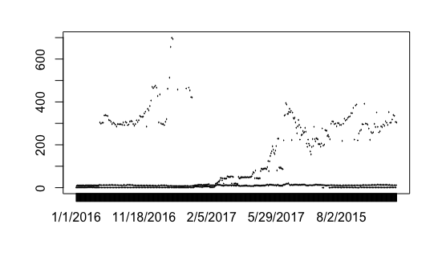

```r
plot(Date.UTC., Value)
```

Now, in order to take advantage of the data variable we will need to transform. If you are new to time series analysis, it is important that you transform your date explanatory variable.

Now, let’s do this the correct way.

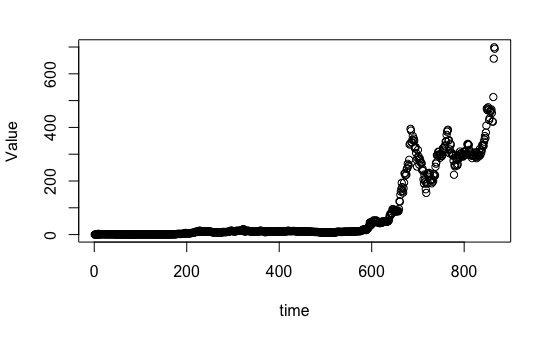

```r
time = 1:866
plot(time, Value)
```

From this plot, we can see that there isn’t really a linear relationship of Value with time. Let’s create a time squared variable and build a simple linear regression model (one without the time squared variable, and one with it).

## Simple Linear Regression Model

```r
m1 = lm(Value~time)
summary(m1)
```

```
Call:
lm(formula = Value ~ time)

Residuals:
    Min      1Q  Median      3Q     Max
-127.37  -72.99    4.16   60.79  443.83

Coefficients:
             Estimate Std. Error t value Pr(>|t|)
(Intercept) -92.46162    5.66996  -16.31   <2e-16 ***
time          0.40199    0.01133   35.48   <2e-16 ***
---
Signif. codes:  0 ‘***’ 0.001 ‘**’ 0.01 ‘*’ 0.05 ‘.’ 0.1 ‘ ’ 1

Residual standard error: 83.36 on 864 degrees of freedom
Multiple R-squared:  0.593, Adjusted R-squared:  0.5925
F-statistic:  1259 on 1 and 864 DF,  p-value: < 2.2e-16
```

It appears that we have a significant model where the F p-value=2.2e-16 < alpha=.05. Let’s see if the squared term will improve the R2 and R2a value

```r
time_sq = time ** 2
m2 = lm(Value~time+time_sq)
summary(m2)
```

```
Call:
lm(formula = Value ~ time + time_sq)

Residuals:
    Min      1Q  Median      3Q     Max
-87.329 -36.385   2.573  30.218 295.398

Coefficients:
              Estimate Std. Error t value Pr(>|t|)
(Intercept)  5.804e+01  5.049e+00   11.50   <2e-16 ***
time        -6.384e-01  2.689e-02  -23.74   <2e-16 ***
time_sq      1.200e-03  3.004e-05   39.95   <2e-16 ***
---
Signif. codes:  0 ‘***’ 0.001 ‘**’ 0.01 ‘*’ 0.05 ‘.’ 0.1 ‘ ’ 1

Residual standard error: 49.41 on 863 degrees of freedom
Multiple R-squared:  0.8571,    Adjusted R-squared:  0.8568
F-statistic:  2589 on 2 and 863 DF,  p-value: < 2.2e-16
```

The residual standard error decreased by half, and the R2 and R2a increased greatly. We now have a model that explains 85.71% of the variation amongst Value, which represents the price of one ether.

Let’s see if we can perform a random walk and conduct some forecasting

## Random Walk and Forecasting

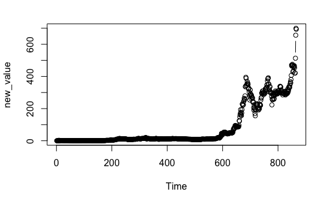

```r
new_value = ts(Value)
plot(new_value, type="b")
```

So it appears that Value isn’t really a random walk. It only becomes a random walk after time 600.

```r
ether[600,1]
```

```
[1] 3/20/2017
866 Levels: 1/1/2016 1/1/2017 1/10/2016 1/10/2017 1/11/2016 ... 9/9/2017
```

If we look at the 600th observation, we find the date to be at 3/20/2017. It makes sense why the data appears to look more like a random walk because this is when the value of ethereum began to become more volatile as more people started to become a part of ethereum (mining, create DApps, etc.).

Let’s make another plot after time 600 to see if it looks more like a random walk.

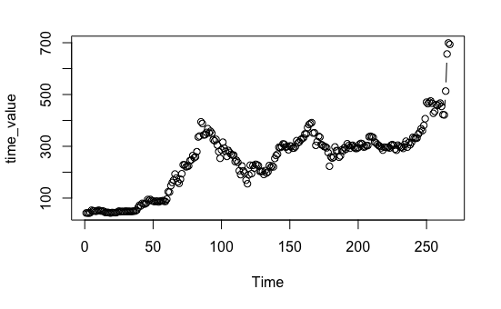

```r
new_value = Value[600:length(Value)]
time_value = ts(new_value)
plot(time_value, type="b")
```

For this random walk let’s conduct some forecasting. We will first see which time lag contributes the most to forecasting the value of ethereum.

## Forecasting

```r
ether[nrow(ether), ]
```

|  | Date.UTC. | UnixTimeStamp | Value |
| --- | --- | --- | --- |
| 866 | 12/14/2017 | 1513209600 | 693.58 |

```r
tail(new_value)
```

```
[1] 422.48 421.15 513.29 656.52 699.09 693.58
```

```r
new_value[length(new_value)]
```

```
[1] 693.58
```

From this output, we find that the last day recorded is on 12/14/2017. The last value of Value is $693.58. Let’s conduct a forecast to today (12/18/2017), and a week from the 14th.

```r
diff = new_value[-1]- new_value[1:1-length(new_value)]
c_bar = mean(diff)
four_days = new_value[length(new_value)] + 4*c_bar
seven_days = new_value[length(new_value)] + 7*c_bar
four_days
```

```
[1] 703.4534
```

```r
seven_days
```

```
[1] 710.8584
```

The random walk forecasts that in 4 days the price of ethereum will be $703.4534 and in a week it will be $710.8584.

## Autocorrelations

```r
acf(time_value, lag.max=20,plot=F)
pacf(time_value, lag.max=20)
```

[output not shown]

```r
yt = new_value[-1]
ylag1= new_value[-length(new_value)]

plot(ylag1, yt)
```

[output not shown]

```r
# AR(1)
m2 = lm(yt~ylag1)
summary(m2)
```

```
Call:
lm(formula = yt ~ ylag1)

Residuals:
    Min      1Q  Median      3Q     Max
-55.390  -7.473  -1.638   5.452 138.648

Coefficients:
            Estimate Std. Error t value Pr(>|t|)
(Intercept) 0.492190   2.599781   0.189     0.85
ylag1       1.007967   0.009481 106.316   <2e-16 ***
---
Signif. codes:  0 ‘***’ 0.001 ‘**’ 0.01 ‘*’ 0.05 ‘.’ 0.1 ‘ ’ 1

Residual standard error: 18.91 on 264 degrees of freedom
Multiple R-squared:  0.9772,    Adjusted R-squared:  0.9771
F-statistic: 1.13e+04 on 1 and 264 DF,  p-value: < 2.2e-16
```

Data Science Rules!

Until next time,

Joel Afriyie